# 11장_최종예제

Seol-Woong, Kim

2021 7 13

문1. ‘한국복지패널데이터’(SPSS, koweps_hpc10_2015_beta5.sav)를 로드한 후 필요한 데이터 변수만을 select하여 변 수명을 변경하시오. 단 필요한 필드로 성별은 gender, 태어난 연도는 birth, 혼인상태는 marriage, 종교는 religion, 월평균임금은 income, 직업코드는 code_job, 지역코드는 code_region로 필드명을 변경한다. 1-1) 필요한 데이터를 다운받아 data.frame으로 load하시오. SPSS파일을 데이터 프레임으로 불러오기

```r
library(foreign)
raw_Welfare <- read.spss(file = 'D:\\Gray_Bigdata\\Downloads\\14_sharedBigdata\\Koweps\\Koweps_hpc10_2015_beta1.sav',
                         to.data.frame = T)
View(raw_Welfare)

raw_welfare <- read.spss(file = 'D:\\Gray_Bigdata\\Downloads\\14_sharedBigdata\\Koweps\\Koweps_hpc10_2015_beta6.sav',
                         to.data.frame = T, reencode = 'utf-8')
```

```
## re-encoding from utf-8
```

```r
dim(raw_welfare)
```

```
## [1] 16664   966
```

1-2) 필요한 필드만 조회

```r
welfare <- raw_welfare[, c('h10_g3', 'h10_g4', 'h10_g10', 'h10_g11', 'h10_eco9',
                       'p1002_8aq1', 'h10_reg7')]
dim(welfare)
```

```
## [1] 16664     7
```

1-3) 필드의 변수명을 변경

```r
library(dplyr)
welfare <- rename(welfare, gender = h10_g3,
                  birth = h10_g4,
                  marriage = h10_g10,
                  religion = h10_g11,
                  code_job = h10_eco9,
                  income = p1002_8aq1,
                  code_region = h10_reg7)
head(welfare)
```

```
##   gender birth marriage religion code_job income code_region
## 1      2  1936        2        2       NA     NA           1
## 2      2  1945        2        2       NA     NA           1
## 3      1  1948        2        2      942    120           1
## 4      1  1942        3        1      762    200           1
## 5      2  1923        2        1       NA     NA           1
## 6      1  1962        1        1      530     NA           1
```

```r
table(is.na(welfare))
```

```
##
## FALSE  TRUE
## 95483 21165
```

```r
colSums(is.na(welfare))
```

```
##      gender       birth    marriage    religion    code_job      income
##           0           0           0           0        9135       12030
## code_region
##           0
```

문2. 1번 문제의 결과인 data.frame변수를 이용하여 성별에 따른 월급 차이가 있는지를 분석하시오. 2-1) gender 필드 변수의 이상치가 있는지 확인하고 이상치 값 처리를 한다.

```r
table(welfare$gender, useNA = 'ifany')
```

```
##
##    1    2
## 7574 9090
```

2-2) gender 필드 변수의 결측치를 확인한다.

```r
table(is.na(welfare$gender))
```

```
##
## FALSE
## 16664
```

2-3) gender의 값이 1은 male로 2는 female로 변경하고 gender의 타입을 factor로 변경한다.

```r
welfare$gender <- ifelse(welfare$gender == 1, "male", "female")

welfare$gender <- factor(welfare$gender, levels = c('male', 'female'))
table(welfare$gender)
```

```
##
##   male female
##   7574   9090
```

2-4) 성별 비율을 도표로 나타내고 그래프로 시각화한다.

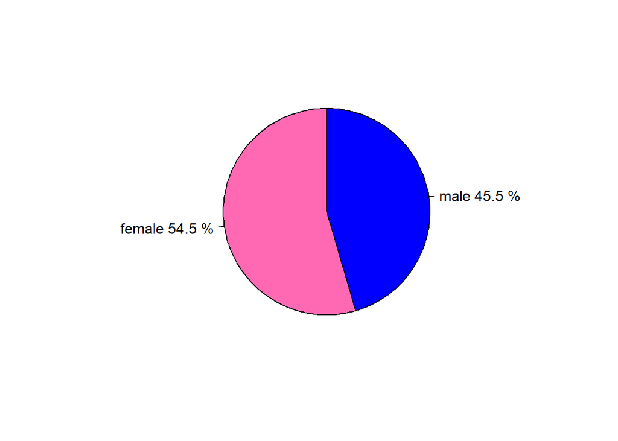

```r
library(dplyr)
library(ggplot2)
gender.ratio <- welfare %>%
  group_by(gender) %>%
  summarise(ratio = n() / nrow(welfare) * 100)

pie(gender.ratio$ratio, labels = paste(gender.ratio$gender,
                                       round(gender.ratio$ratio, 1),
                                       '%'), clockwise = T, col = c('blue', 'hotpink'))
```

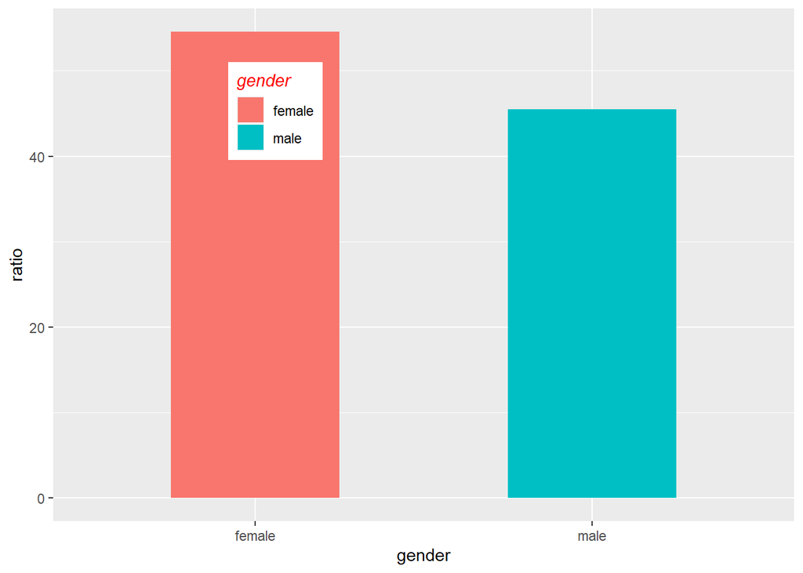

```r
ggplot(gender.ratio, aes(x = gender, y = ratio, fill = gender)) +
  geom_col(width = 0.5) +
  theme(legend.position = c(0.3, 0.8),
        legend.title = element_text(face = 3, color = 'red')) +
  scale_x_discrete(limits = c('female', 'male')) +
  scale_fill_discrete(limits = c('female', 'male'))
```

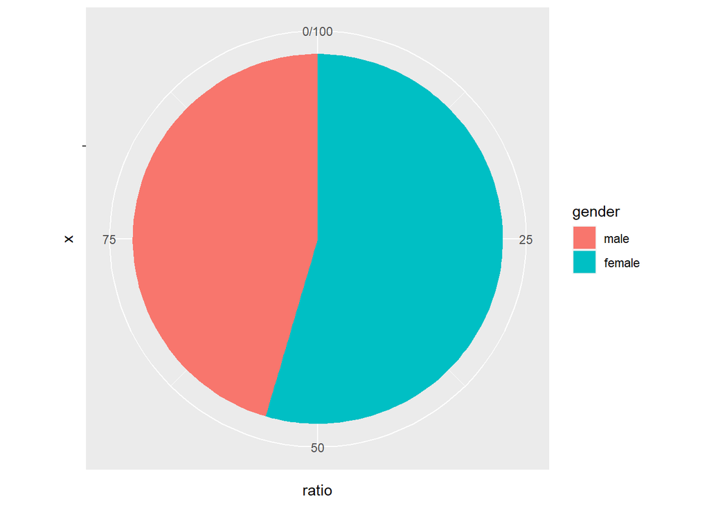

```r
ggplot(gender.ratio, aes(x = "", y = ratio, fill = gender)) +
  geom_col() +
  coord_polar("y")
```

2-5) income의 최소값, 1분위수, 중위수, 3분위수, 최대값, 결측치 등을 탐색하고, boxplot과 월급의 빈 도그래프를 시각화한다.

```r
summary(welfare$income)
```

```
##    Min. 1st Qu.  Median    Mean 3rd Qu.    Max.    NA's
##     0.0   122.0   192.5   241.1   316.6  1853.3   12030
```

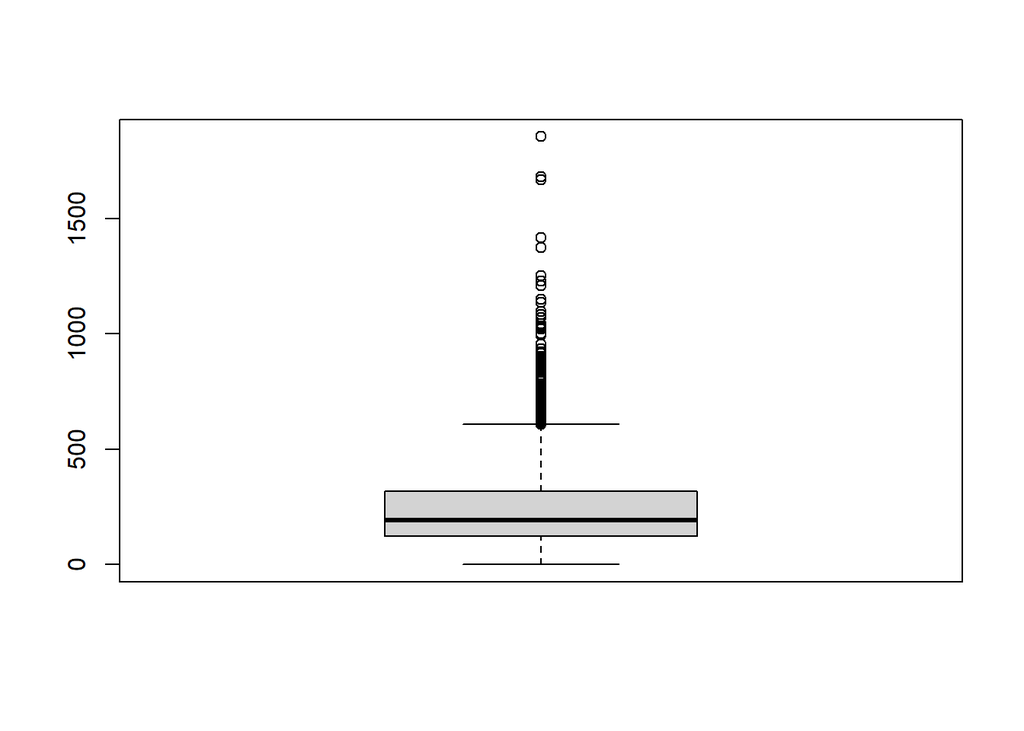

```r
boxplot(welfare$income)
```

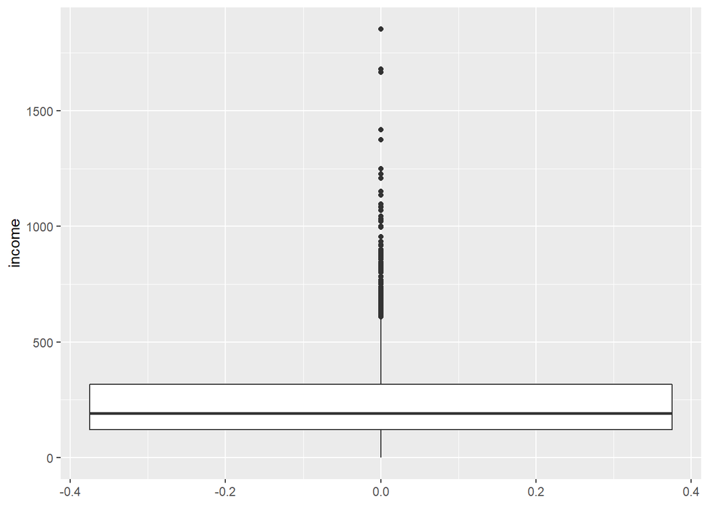

```r
ggplot(welfare, aes(y = income)) +
  geom_boxplot()
```

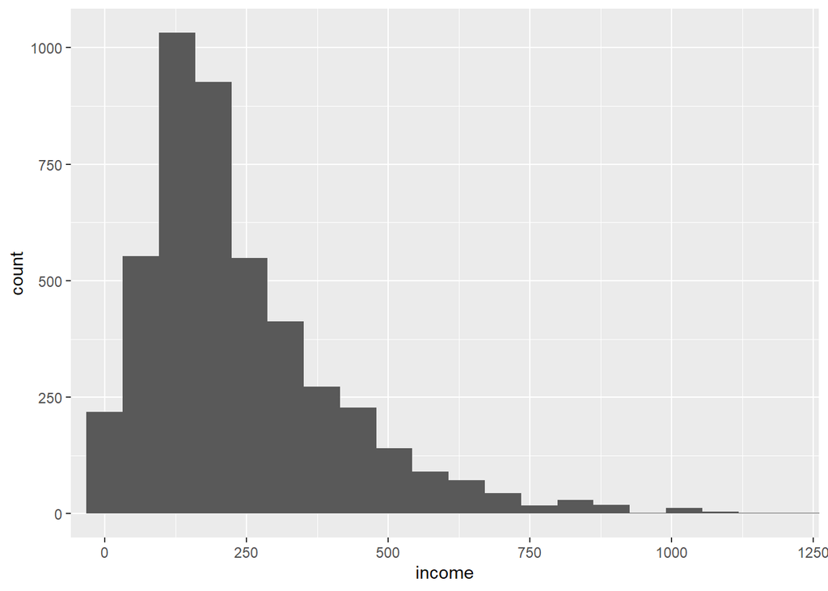

```r
ggplot(welfare, aes(income)) +
  geom_histogram() +
  coord_cartesian(xlim = c(0, 1200))
```

2-6) income이 0인 데이터는 이상치로 정하고, 이상치를 결측 처리한다.

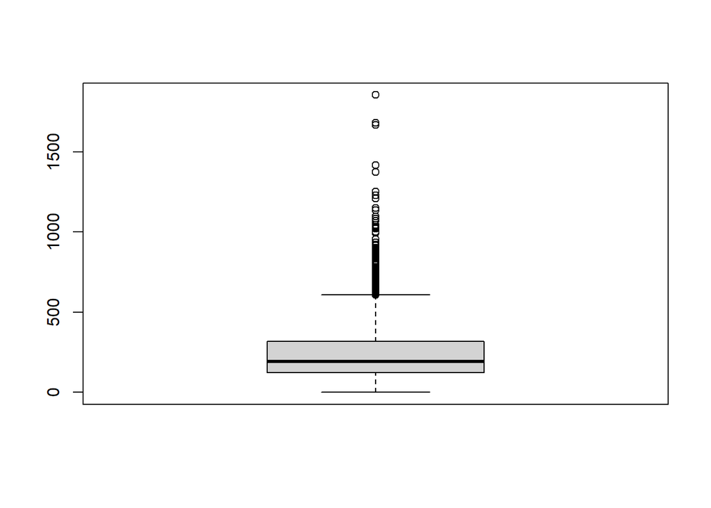

```r
b <- boxplot(welfare$income)$stat
```

```r
table(welfare$income <= b[1])
```

```
##
## FALSE  TRUE
##  4620    14
```

```r
welfare$income <- ifelse(welfare$income <= b[1], NA, welfare$income)
table(welfare$income <= b[1])
```

```
##
## FALSE
##  4620
```

```r
table(welfare$income <= b[5], useNA = 'ifany')
```

```
##
## FALSE  TRUE  <NA>
##   207  4413 12044
```

```r
table(welfare$income > b[5], exclude = NULL)
```

```
##
## FALSE  TRUE  <NA>
##  4413   207 12044
```

2-7) 결측치를 제외한 데이터를 이용하여 성별에 따른 월급차이가 있는지를 분석한다.

```r
library(dplyr)
library(doBy)
temp <- welfare[, c('gender', 'income')]
m <- tapply(temp$income, temp$gender, median, na.rm = T)
temp$income <- ifelse(is.na(temp$income), m[temp$gender], temp$income)

summaryBy(income ~ gender, data = welfare, FUN = c(mean, sd), na.rm = T)
```

```
##   gender income.mean income.sd
## 1   male    312.2932  198.6950
## 2 female    162.2323  116.5352
```

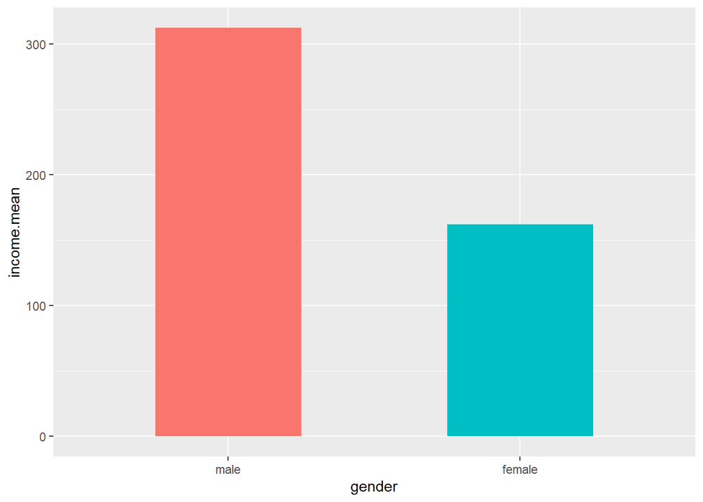

```r
welfare %>%
  group_by(gender) %>%
  summarise(income.mean = mean(income, na.rm = T)) %>%
  ggplot(aes(x = gender, y = income.mean, fill = gender)) +
  geom_bar(stat = "identity", width = 0.5) +
  theme(legend.position = "none")
```

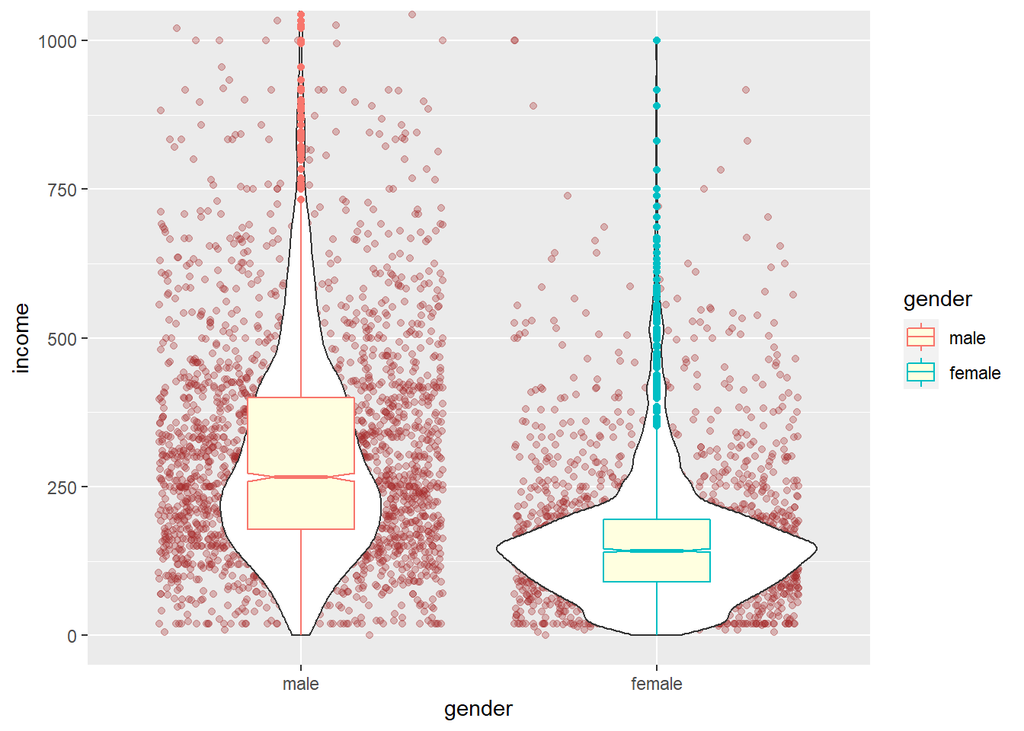

```r
ggplot(welfare, aes(x = gender, y = income)) +
  geom_point(position = 'jitter', col = 'brown', alpha = 0.3) +
  geom_violin() +
  geom_boxplot(aes(col = gender), fill = 'lightyellow',
               width = 0.3, notch = T) +
  coord_cartesian(ylim = c(0, 1000))
```

```r
t.test(income ~ gender, data = welfare)
```

```
##
##  Welch Two Sample t-test
##
## data:  income by gender
## t = 31.731, df = 4037.8, p-value < 2.2e-16
## alternative hypothesis: true difference in means between group male and group female is not equal to 0
## 95 percent confidence interval:
##  140.7891 159.3326
## sample estimates:
##   mean in group male mean in group female
##             312.2932             162.2323
```

문3. 1번 문제의 결과인 data.frame변수를 이용하여 나이와 월급의 관계를 분석하여 몇 살 때 월급을 가장 많이 받 는지 시각화하시오. 3-1) birth, income 필드 변수의 이상치와 결측치를 확인한다.

```r
table(welfare$birth, useNA = 'ifany')
```

```
##
## 1907 1911 1914 1915 1917 1918 1919 1920 1921 1922 1923 1924 1925 1926 1927 1928
##    1    1    1    1    1    3    5   10   13   18   27   22   38   33   53   54
## 1929 1930 1931 1932 1933 1934 1935 1936 1937 1938 1939 1940 1941 1942 1943 1944
##   68   93  121  174  156  196  225  259  266  278  305  291  262  356  266  232
## 1945 1946 1947 1948 1949 1950 1951 1952 1953 1954 1955 1956 1957 1958 1959 1960
##  195  228  268  193  207  203  155  225  168  195  204  209  196  200  205  246
## 1961 1962 1963 1964 1965 1966 1967 1968 1969 1970 1971 1972 1973 1974 1975 1976
##  214  220  203  207  214  193  198  230  219  243  253  233  239  257  229  201
## 1977 1978 1979 1980 1981 1982 1983 1984 1985 1986 1987 1988 1989 1990 1991 1992
##  191  193  206  185  177  182  158  111  118  130   92  139  135  131  170  149
## 1993 1994 1995 1996 1997 1998 1999 2000 2001 2002 2003 2004 2005 2006 2007 2008
##  122  167  177  189  201  192  209  214  193  185  171  169  146  168  154  162
## 2009 2010 2011 2012 2013 2014
##  132  149  152  118  117   31
```

```r
table(is.na(welfare$birth))
```

```
##
## FALSE
## 16664
```

```r
table(welfare$income, useNA = 'ifany')
```

[output not shown]

[output cut: 300 more lines]

[output not shown]

```r
table(is.na(welfare$income))
```

```
##
## FALSE  TRUE
##  4620 12044
```

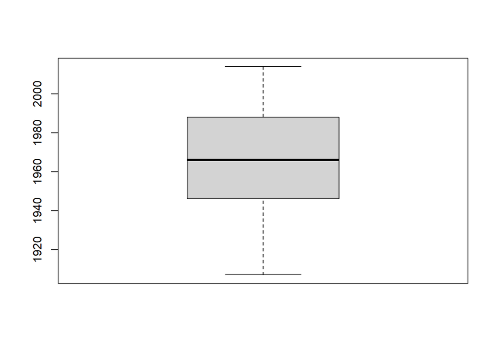

```r
boxplot(welfare$birth)
```

3-2) birth변수를 이용하여 나이를 계산하고 이 값을 age 필드로 추가한다.

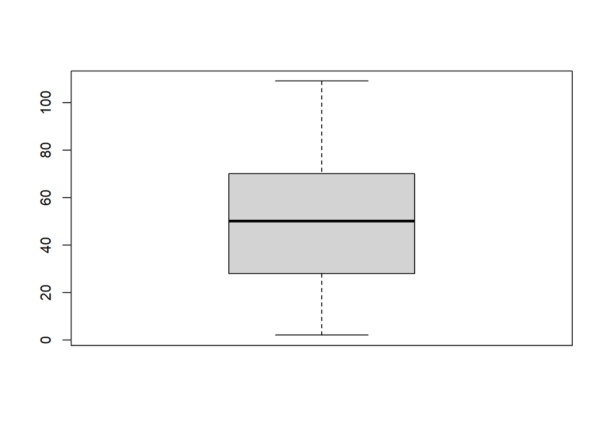

```
##      [,1]
## [1,]    2
## [2,]   28
## [3,]   50
## [4,]   70
## [5,]  109
```

```r
welfare$age <- 2015 - welfare$birth + 1

boxplot(welfare$age)$stat
```

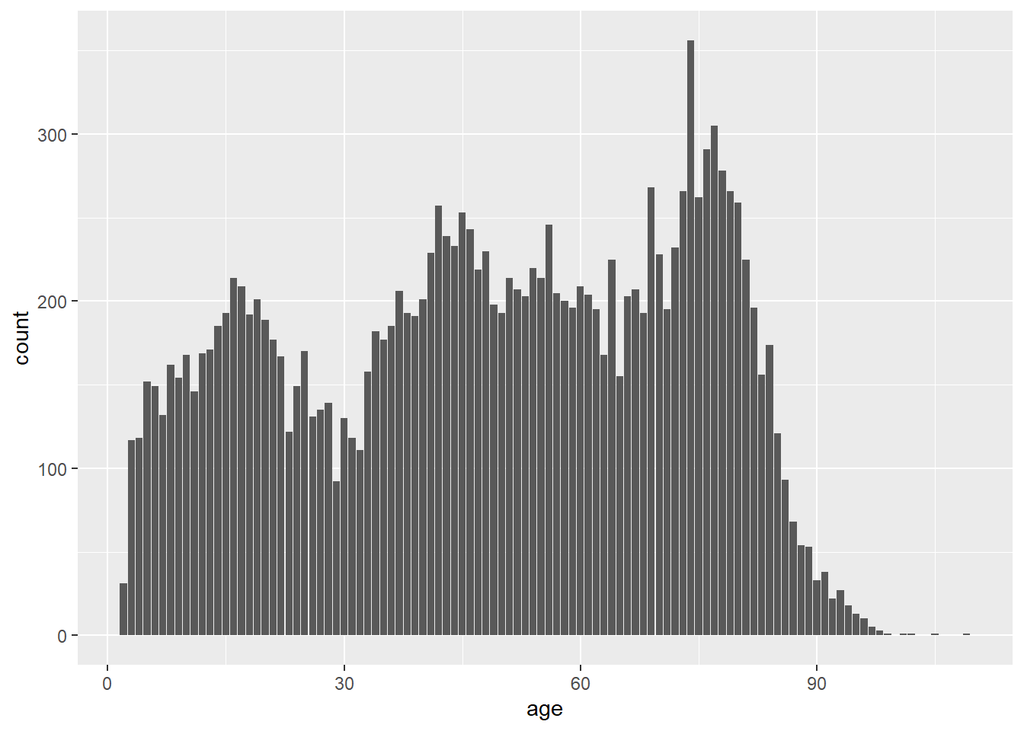

```r
ggplot(data = welfare, aes(age)) +
  geom_bar()
```

3-3) x축을 나이, y축을 월급으로 지정하고 나이에 따른 월급의 변화가 표현되도록 막대그래프나 선 그래프로 시각화한다.

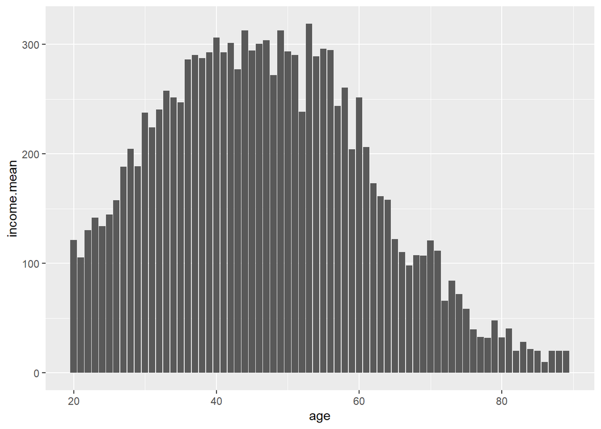

```r
library(dplyr)
age_income <- welfare %>%
  filter(!is.na(welfare$income)) %>%
  group_by(age) %>%
  summarise(income.mean = mean(income),
            income.sd   = sd(income))

ggplot(age_income, aes(x=age, y=income.mean)) +
  geom_col()
```

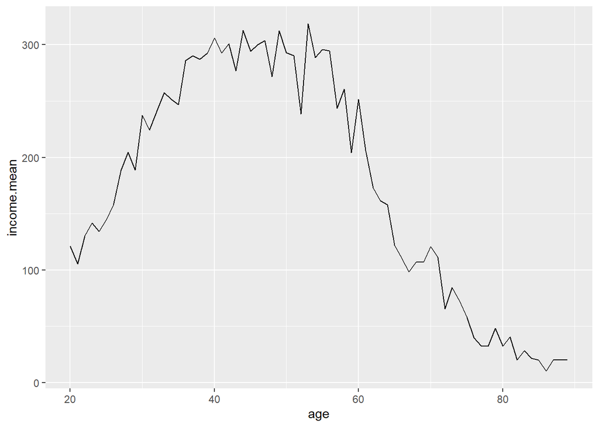

```r
ggplot(age_income, aes(x=age, y=income.mean)) +
  geom_line()
```

3-4) 나이에 따른 월급의 차이가 있는지 관계를 분석한다.

```r
fit <- lm(income ~ age, data = welfare)
anova(fit)
```

```
## Analysis of Variance Table
##
## Response: income
##             Df    Sum Sq Mean Sq F value    Pr(>F)
## age          1   3173944 3173944  98.417 < 2.2e-16 ***
## Residuals 4618 148929914   32250
## ---
## Signif. codes:  0 '***' 0.001 '**' 0.01 '*' 0.05 '.' 0.1 ' ' 1
```

3-5) 가장 월급이 많은 나이

```r
head(age_income[order(-age_income$income.mean), ], 1)
```

```
## # A tibble: 1 x 3
##     age income.mean income.sd
##   <dbl>       <dbl>     <dbl>
## 1    53        319.      243.
```

문4. 1번 문제의 결과인 data.frame변수를 이용하여 연령대에 따른 월급의 차이가 있는지, 있으면 어떤 연령대가 월급이 가장 많은지 분석하시오. 단, 연령대는 30세 이하는 young, 31~60세는 middle, 61세 이상은 old로 분류한다. 4-1) 파생변수 agegrade를 필드로 추가한다.

```r
welfare$agegrade <- ifelse(welfare$age <= 30, 'young', ifelse(welfare$age > 30 & welfare$age < 61, 'middle', 'old'))
welfare$agegrade <- factor(welfare$agegrade, levels = c('young', 'middle', 'old'))

head(welfare, 10)
```

```
##    gender birth marriage religion code_job income code_region age agegrade
## 1  female  1936        2        2       NA     NA           1  80      old
## 2  female  1945        2        2       NA     NA           1  71      old
## 3    male  1948        2        2      942    120           1  68      old
## 4    male  1942        3        1      762    200           1  74      old
## 5  female  1923        2        1       NA     NA           1  93      old
## 6    male  1962        1        1      530     NA           1  54   middle
## 7  female  1963        1        1       NA     NA           1  53   middle
## 8  female  2003        0        1       NA     NA           1  13    young
## 9    male  1927        1        1       NA     NA           1  89      old
## 10 female  1934        1        1       NA     NA           1  82      old
```

4-2) agegrade 의 분포를 도표와 그래프로 시각화한다.

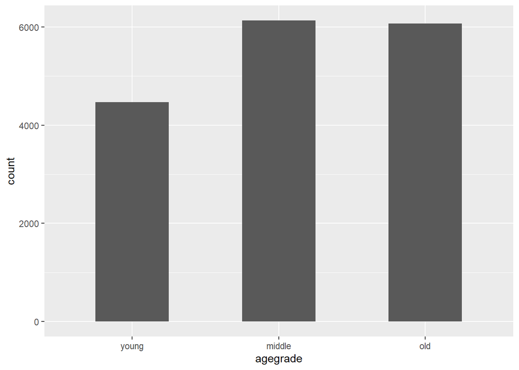

```r
library(ggplot2)
ggplot(welfare, aes(agegrade)) +
  geom_bar(width = 0.5)
```

4-3) 연령대 별 월급의 boxplot을 시각화한다.

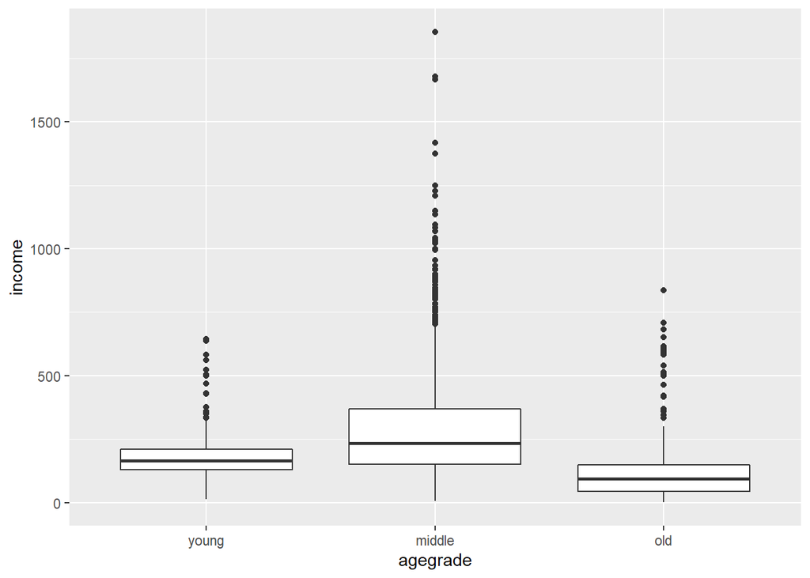

```r
library(ggplot2)
ggplot(welfare, aes(x = agegrade, y = income, na.rm = T)) +
  geom_boxplot()
```

4-4) 실제로 연령대에 따른 월급 차이가 있는지 분석한다.

```r
fit <- lm(income ~ agegrade, data = welfare)
anova(fit)
```

```
## Analysis of Variance Table
##
## Response: income
##             Df    Sum Sq Mean Sq F value    Pr(>F)
## agegrade     2  19972207 9986103  348.94 < 2.2e-16 ***
## Residuals 4617 132131651   28619
## ---
## Signif. codes:  0 '***' 0.001 '**' 0.01 '*' 0.05 '.' 0.1 ' ' 1
```

문5. 1번 문제의 결과인 data.frame변수를 이용하여 성별에 따른 월급의 차이는 연령대 별로 다른지 분석하시오. 5-1) 성별, 연령대, 월급 데이터의 결측치를 확인한다.

```r
table(is.na(welfare$gender))
```

```
##
## FALSE
## 16664
```

```r
table(is.na(welfare$agegrade))
```

```
##
## FALSE
## 16664
```

```r
table(is.na(welfare$income))
```

```
##
## FALSE  TRUE
##  4620 12044
```

5-2) 연령대별, 성별 월급의 평균과 표준편차, 빈도를 출력한다.

```r
library(dplyr)
welfare %>%
  group_by(agegrade) %>%
  summarise(agegrade_mean = mean(income, na.rm = T),
            agegrade_sd = sd(income, na.rm = T),
            agegrade_cnt = n())
```

```
## # A tibble: 3 x 4
##   agegrade agegrade_mean agegrade_sd agegrade_cnt
##   <fct>            <dbl>       <dbl>        <int>
## 1 young             174.        86.8         4464
## 2 middle            282.       190.          6130
## 3 old               113.       103.          6070
```

```r
welfare %>%
  group_by(gender) %>%
  summarise(gender_mean = mean(income, na.rm = T),
            gender_sd = sd(income, na.rm = T),
            gender_cnt = n())
```

```
## # A tibble: 2 x 4
##   gender gender_mean gender_sd gender_cnt
##   <fct>        <dbl>     <dbl>      <int>
## 1 male          312.      199.       7574
## 2 female        162.      117.       9090
```

5-3) 성별에 따른 월급의 차이가 연령대별로 다른지 시각화 한다.

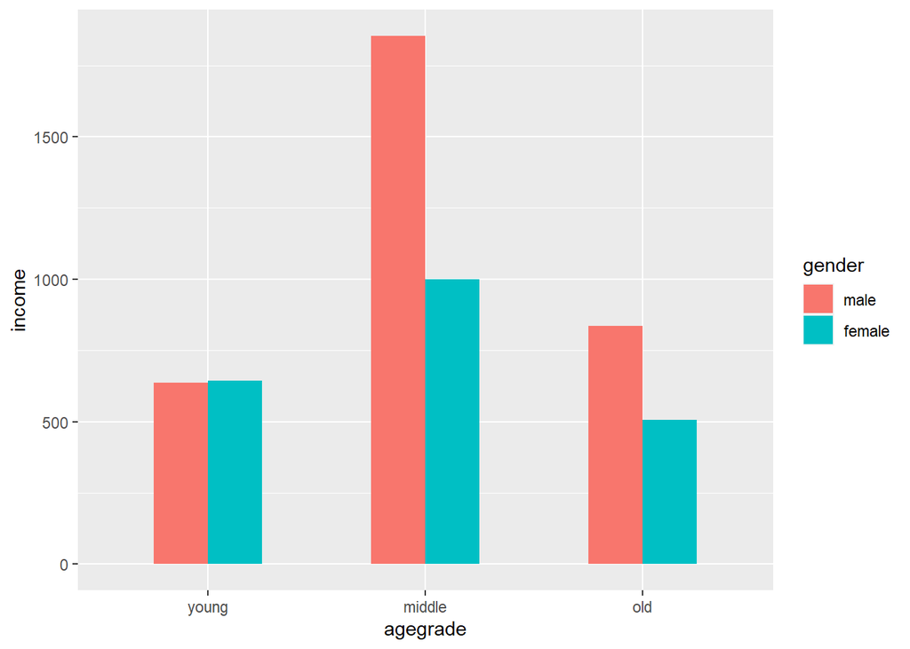

```r
library(ggplot2)
ggplot(welfare, aes(x = agegrade, y = income, na.rm = T)) +
  geom_col(aes(fill = gender), width = 0.5, position = position_dodge())
```

문6. 1번 문제의 결과인 data.frame변수를 이용하여 나이에 따른 월급 변화를 성별을 분리하여 시각화 하시오. 6-1) 나이와 성별로 group_by하여 월급평균, 월급표준편차, 월급중앙값, 최소값과 최대값, 빈도을 산출한다.

```r
library(dplyr)
table(is.na(welfare$income))
```

```
##
## FALSE  TRUE
##  4620 12044
```

```r
welfare %>%
  group_by(age, gender) %>%
  summarise(mean = mean(income, na.rm = TRUE),
            sd = sd(income, na.rm = TRUE),
            median = median(income, na.rm = TRUE),
            min = min(income, na.rm = TRUE),
            max = max(income, na.rm = TRUE),
            cnt = n())
```

[output not shown]

[output cut: 136 more lines]

[output not shown]

[output not shown]

[output cut: 136 more lines]

[output not shown]

```
## # A tibble: 199 x 8
## # Groups:   age [102]
##      age gender  mean    sd median   min   max   cnt
##    <dbl> <fct>  <dbl> <dbl>  <dbl> <dbl> <dbl> <int>
##  1     2 male     NaN    NA     NA   Inf  -Inf    12
##  2     2 female   NaN    NA     NA   Inf  -Inf    19
##  3     3 male     NaN    NA     NA   Inf  -Inf    60
##  4     3 female   NaN    NA     NA   Inf  -Inf    57
##  5     4 male     NaN    NA     NA   Inf  -Inf    58
##  6     4 female   NaN    NA     NA   Inf  -Inf    60
##  7     5 male     NaN    NA     NA   Inf  -Inf    73
##  8     5 female   NaN    NA     NA   Inf  -Inf    79
##  9     6 male     NaN    NA     NA   Inf  -Inf    79
## 10     6 female   NaN    NA     NA   Inf  -Inf    70
## # ... with 189 more rows
```

6-2) 나이에 따른 월급평균의 추이를 아래와 같은 그래프를 시각화하고, 아래의 그래프를 파일로도 출력한다.

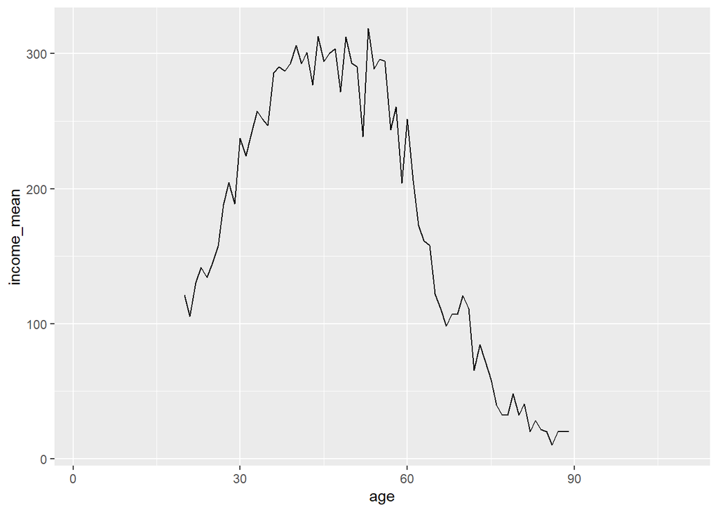

```r
library(dplyr)
welfare %>%
  group_by(age) %>%
  summarise(income_mean = mean(income, na.rm = T)) %>%
  ggplot(aes(x = age, y = income_mean)) +
  geom_line()
```

```r
ggsave(filename = 'D:\\Gray_Bigdata\\src\\06_R\\cap.png')
```

문7. 1번 문제의 결과인 data.frame변수를 이용하여 직업별 월급의 차이가 나는지 분석하고, 만약 월급의 차이가 나면 어떤 직업이 월급이 가장 많은지 상위 10개 직업군만 시각화하시오. 7-1) 직업별 월급 평균, 표준편차, 빈도를 평균월급 순으로 정렬하여 출력하여 직업별 월급의 추이를 분석한다.

```r
library(readxl)
job_xlsx <- read_xlsx('D:\\Gray_Bigdata\\Downloads\\14_sharedBigdata\\Koweps\\Koweps_Codebook.xlsx', sheet = 2)
head(job_xlsx)
```

```
## # A tibble: 6 x 2
##   code_job job
##      <dbl> <chr>
## 1      111 의회의원 고위공무원 및 공공단체임원
## 2      112 기업고위임원
## 3      120 행정 및 경영지원 관리자
## 4      131 연구 교육 및 법률 관련 관리자
## 5      132 보험 및 금융 관리자
## 6      133 보건 및 사회복지 관련 관리자
```

```r
welfare <- left_join(welfare, job_xlsx, by = "code_job") # left join은 데이터프레임들끼리 가능

welfare %>% group_by(job) %>%
  summarise(income_mean = mean(income, na.rm = T),
            income_sd = sd(income, na.rm = T),
            income_cnt = n()) %>%
  arrange(income_mean)
```

```
## # A tibble: 146 x 4
##    job                          income_mean income_sd income_cnt
##    <chr>                              <dbl>     <dbl>      <int>
##  1 가사 및 육아 도우미                 80.2      43.4        125
##  2 임업관련 종사자                     83.3      NA            2
##  3 기타 서비스관련 단순 종사원         88.2      73.7        141
##  4 청소원 및 환경 미화원               88.8      82.1        325
##  5 약사 및 한약사                      89        NA            4
##  6 작물재배 종사자                     92        87.1       1320
##  7 농립어업관련 단순 종사원           102.       61.6         45
##  8 의료 복지 관련 서비스 종사자       104.       55.8        124
##  9 음식관련 단순 종사원               108.       55.5        122
## 10 판매관련 단순 종사원               117.       51.7         73
## # ... with 136 more rows
```

7-2) 직업별 월급의 차이를 분석한 후, 상위 소득 10개 직업군을 도표로 출력하고, 아래와 같은 그래프로 시각화한다. 시각화한 그래프는 ggsave함수를 이용하여 top10.png라는 그림파일로 저장한다.

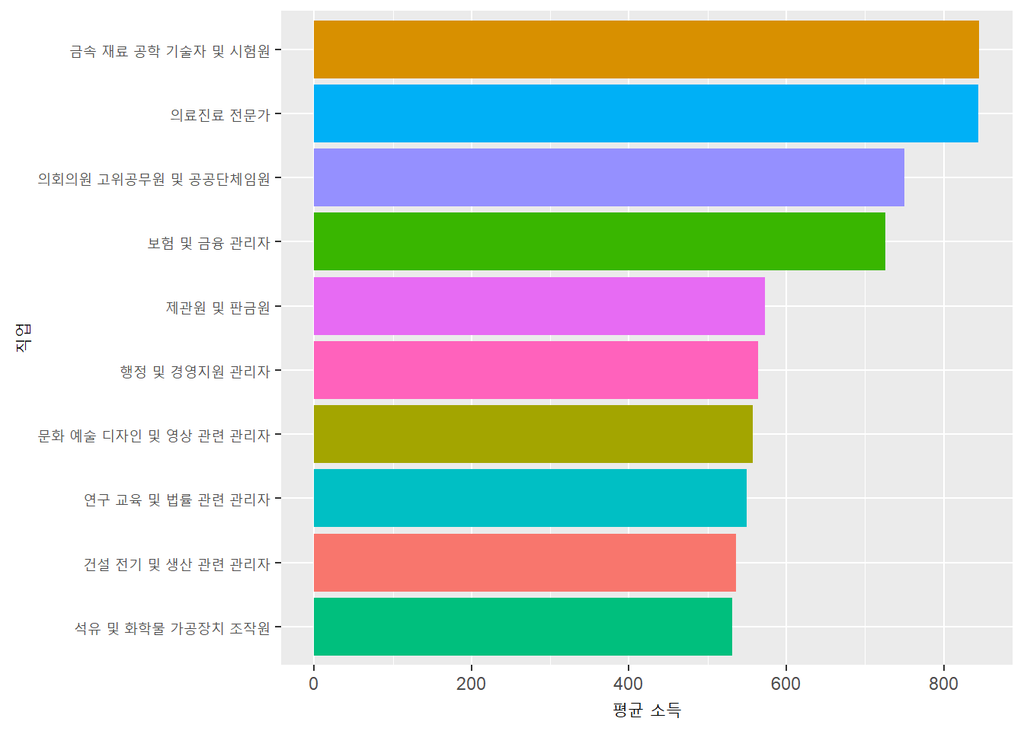

```r
library(ggplot2)
welfare %>%
  group_by(job) %>%
  summarise(income_mean = mean(income, na.rm = T)) %>%
  arrange(desc(income_mean)) %>%
  head(10) %>%
  ggplot(aes(x = income_mean, y = reorder(job, income_mean), fill = job)) +
  geom_col() +
  theme(legend.position = 'none') +
  labs(x = '평균 소득', y = '직업')
```

```r
ggsave(filename = 'D:\\Gray_Bigdata\\src\\06_R\\top10.png')
```

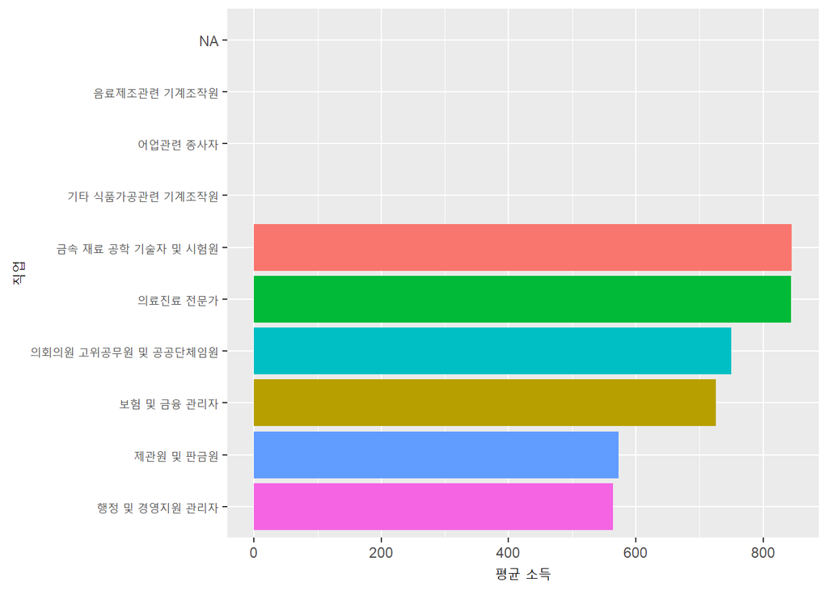

```r
welfare %>%
  group_by(job) %>%
  summarise(income_mean = mean(income, na.rm = T)) %>%
  arrange(income_mean) %>%
  tail(10) %>%
  ggplot(aes(x = income_mean, y = reorder(job, income_mean), fill = job)) +
  geom_col() +
  theme(legend.position = 'none') +
  labs(x = '평균 소득', y = '직업')
```

```r
welfare %>%
  filter(welfare$gender == 2) %>%
  group_by(code_job) %>%
  summarise(cnt = n()) %>%
  arrange(desc(cnt)) %>%
  head(10)
```

```
## # A tibble: 0 x 2
## # ... with 2 variables: code_job <dbl>, cnt <int>
```

```r
welfare %>%
  filter(welfare$gender == 1) %>%
  group_by(code_job) %>%
  summarise(cnt = n()) %>%
  arrange(desc(cnt)) %>%
  head(10)
```

```
## # A tibble: 0 x 2
## # ... with 2 variables: code_job <dbl>, cnt <int>
```

문9. 1번 문제의 결과인 data.frame변수를 이용하여 종교 유무에 따른 이혼률을 분석하시오. 9-1) 종교 데이터인 religion 필드의 이상치 및 결측치를 확인한다.

```r
table(is.na(welfare$religion))
```

```
##
## FALSE
## 16664
```

9-2) religion 필드가 1이면 “종교-유”, 2이면 “종교-무”로 데이터를 변경한다.

```r
welfare$religion <- ifelse(welfare$religion == 1, '종교-유', '종교-무')
```

9-3) 종교 유무의 빈도를 시각화한다.

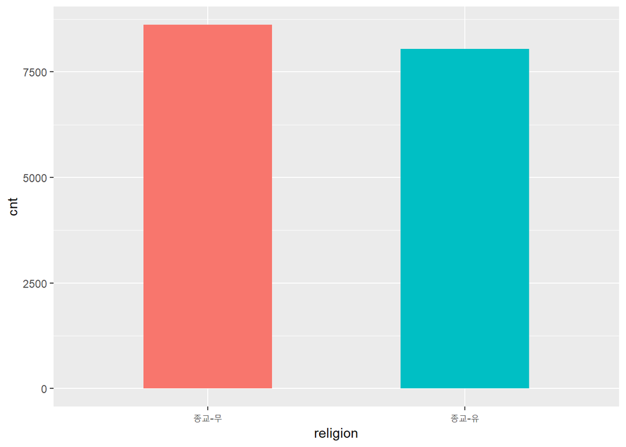

```r
welfare %>%
  group_by(religion) %>%
  summarise(cnt = n()) %>%
  ggplot(aes(x = religion, y = cnt, fill = religion)) +
  geom_bar(stat = 'identity', width = 0.5) +
  theme(legend.position = 'none')
```

9-4) 혼인 상태 데이터인 marriage 필드가 1이면 “기혼”, 3이면 “이혼”으로, 그 외는 NA로 값을 같은 marriage_group 파생변수를 추가한다.

```r
table(welfare$marriage)
```

```
##
##    0    1    2    3    4    5    6
## 2861 8431 2117  712   84 2433   26
```

```r
welfare$marriage_group <- ifelse(welfare$marriage == 1, '기혼', ifelse(welfare$marriage == 3, '이혼', NA))
```

9-5) 종교 유무에 따른 이혼률을 분석한다.

```r
temp <- welfare %>%
  filter(!is.na(marriage_group))

var.test(data = temp, marriage ~ religion)
```

```
##
##  F test to compare two variances
##
## data:  marriage by religion
## F = 1.1413, num df = 4601, denom df = 4540, p-value = 8.064e-06
## alternative hypothesis: true ratio of variances is not equal to 1
## 95 percent confidence interval:
##  1.076945 1.209382
## sample estimates:
## ratio of variances
##           1.141251
```

```r
t.test(data = temp, marriage ~ religion, var.equal = F) # p-value가 0.05 미만이므로 종교 유무에 따른 결혼
```

```
##
##  Welch Two Sample t-test
##
## data:  marriage by religion
## t = 2.0013, df = 9115.7, p-value = 0.04539
## alternative hypothesis: true difference in means between group 종교-무 and group 종교-유 is not equal to 0
## 95 percent confidence interval:
##  0.0004598197 0.0443849626
## sample estimates:
## mean in group 종교-무 mean in group 종교-유
##              1.166884              1.144462
```

```r
                                                        # 상태가 다를 수 있다.
```

9-6) 분석한 결과를 도표와 그래프로 시각화한다.

```r
religion_marriage <- welfare %>%
  filter(!is.na(marriage_group)) %>%
  group_by(religion, marriage_group) %>%
  summarise(cnt = n(), groups = "drop") %>%
  group_by(religion) %>%
  mutate(tot_group = sum(cnt)) %>%
  mutate(ratio = round(cnt / tot_group *100, 1))
religion_marriage
```

```
## # A tibble: 4 x 6
## # Groups:   religion [2]
##   religion marriage_group   cnt groups tot_group ratio
##   <chr>    <chr>          <int> <chr>      <int> <dbl>
## 1 종교-무  기혼            4218 drop        4602  91.7
## 2 종교-무  이혼             384 drop        4602   8.3
## 3 종교-유  기혼            4213 drop        4541  92.8
## 4 종교-유  이혼             328 drop        4541   7.2
```

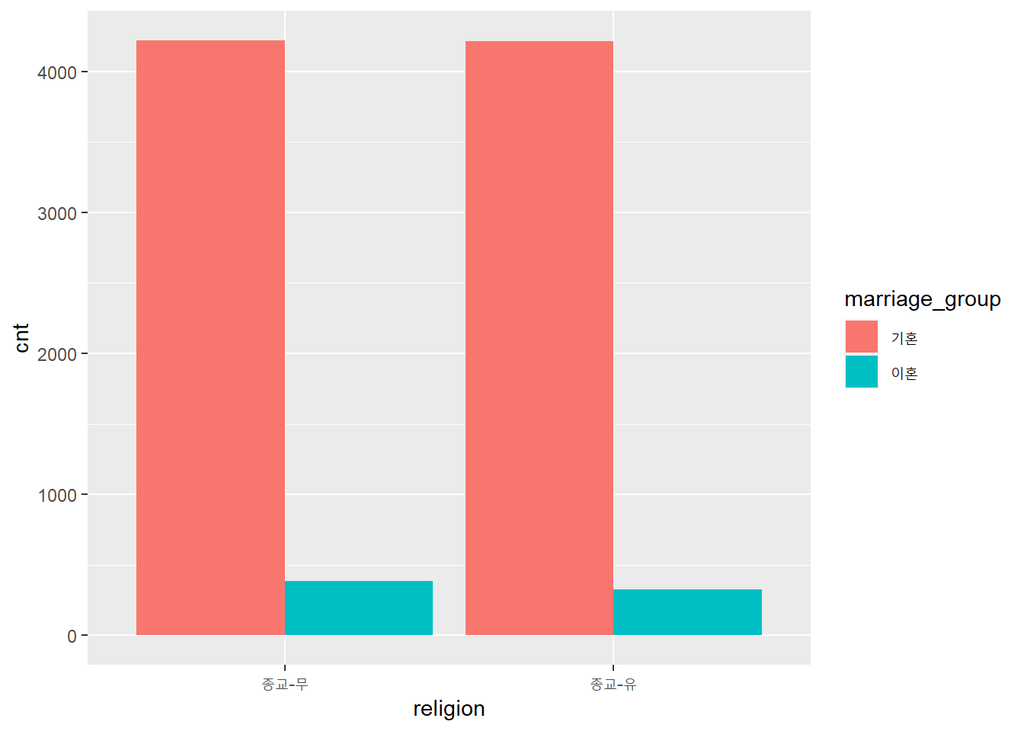

```r
ggplot(religion_marriage, aes(x = religion, y = cnt, fill = marriage_group)) +
  geom_col(position = position_dodge())
```

문10. 1번 문제의 결과인 data.frame변수를 이용하여 지역별 연령대 비율을 분석하시오. 노년층이 많은 지역은 어 디인지 출력하시오. 10-1) 결측치를 확인한다.

```r
table(is.na(welfare$region))
```

```
## < table of extent 0 >
```

```r
table(is.na(welfare$age))
```

```
##
## FALSE
## 16664
```

10-2) region 파생변수를 지역명으로 추가한다. 1:서울 2:수도권(인천/경기) 3:부산/경남/울산 4:대구/경북 5:대전/충남 6:강원/충북 7:광주/전남/전북/제주도

```r
welfare$region <- welfare$code_region

welfare$region <- ifelse(welfare$code_region == 1, '서울', welfare$region)
welfare$region <- ifelse(welfare$code_region == 2, '수도권(인천/경기)', welfare$region)
welfare$region <- ifelse(welfare$code_region == 3, '부산/경남/울산', welfare$region)
welfare$region <- ifelse(welfare$code_region == 4, '대구/경북', welfare$region)
welfare$region <- ifelse(welfare$code_region == 5, '대전/충남', welfare$region)
welfare$region <- ifelse(welfare$code_region == 6, '강원/충북', welfare$region)
welfare$region <- ifelse(welfare$code_region == 7, '광주/전남/전북/제주도', welfare$region)
```

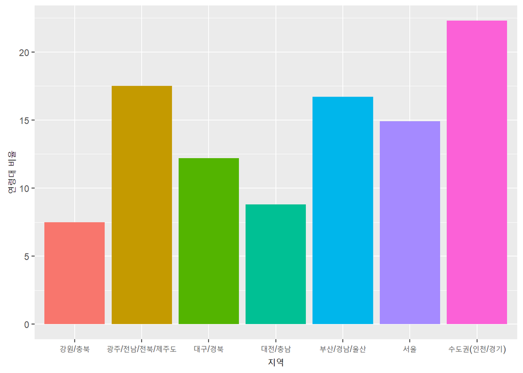

```r
welfare %>%
  group_by(region) %>%
  summarise(cnt = n()) %>%
  mutate(tot_peo = sum(cnt)) %>%
  mutate(ratio = round(cnt / tot_peo * 100, 1)) %>%
  ggplot(aes(x = region, y = ratio, fill = region)) +
  geom_bar(stat = 'identity') +
  theme(legend.position = 'none') +
  labs(x = '지역', y = '연령대 비율')
```

10-4) 노년층이 많은 지역이 어디인지 시각화한다.

```r
table(welfare$agegrade)
```

```
##
##  young middle    old
##   4464   6130   6070
```

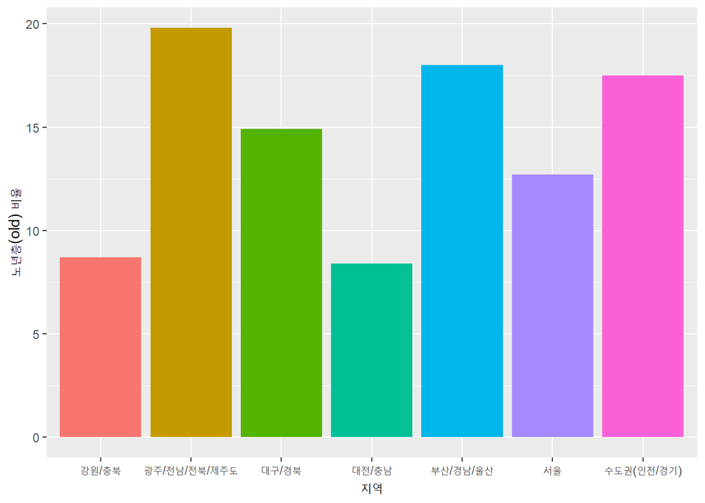

```r
welfare %>%
  filter(agegrade == 'old') %>%
  group_by(region) %>%
  summarise(cnt = n()) %>%
  mutate(tot_peo = sum(cnt)) %>%
  mutate(ratio = round(cnt / tot_peo * 100, 1)) %>%
  ggplot(aes(x = region, y = ratio, fill = region)) +
  geom_bar(stat = 'identity') +
  theme(legend.position = 'none') +
  labs(x = '지역', y = '노년층(old) 비율')
```